# 04 - Clean & Seal Cutoff Analysis (Updated)

PhillyStat360

2026-02-21

# 1. Load Data

```r
clean_seal <- read_csv(paste0(data_path, "clean_seal.csv"), show_col_types = FALSE) %>%
  janitor::clean_names()

properties <- read_csv(paste0(data_path, "opa_properties_public.csv"), show_col_types = FALSE) %>%
  janitor::clean_names()

violations <- read_csv(paste0(data_path, "violations.csv"), show_col_types = FALSE) %>%
  janitor::clean_names()

licenses <- read_csv(paste0(data_path, "business_licenses.csv"), show_col_types = FALSE) %>%
  janitor::clean_names()
```

# 2. Clean & Seal Field Exploration

Before deciding on cutoff strategy, we need to understand what status/date fields are available.

```r
# List all columns
cat("All columns in clean_seal:\n")
```

```
## All columns in clean_seal:
```

```r
cat(paste(names(clean_seal), collapse = "\n"))
```

```
## the_geom
## the_geom_webmercator
## objectid
## addressobjectid
## parcel_id_num
## casenumber
## casepriority
## caseresponsibility
## casecreateddate
## casecompleteddate
## mostrecentinvestigation
## workordertype
## workordercompleteddate
## workordernumber
## workorderstatus
## opa_account_num
## address
## unit_type
## unit_num
## zip
## censustract
## opa_owner
## systemofrecord
## geocode_x
## geocode_y
## council_district
## posse_jobid
## lat
## lng
```

```r
# Identify date-related columns
date_cols <- names(clean_seal)[str_detect(tolower(names(clean_seal)), "date|completed")]
cat("\nDate-related columns:", paste(date_cols, collapse = ", "), "\n")
```

```
##
## Date-related columns: casecreateddate, casecompleteddate, workordercompleteddate
```

```r
# Identify status-related columns
status_cols <- names(clean_seal)[str_detect(tolower(names(clean_seal)), "status")]
cat("Status-related columns:", paste(status_cols, collapse = ", "), "\n")
```

```
## Status-related columns: workorderstatus
```

## 2a. Work Order Status Breakdown

`workorderstatus` tells us whether the boarding-up work was actually carried out.

```r
clean_seal %>%
  filter(!is.na(opa_account_num)) %>%
  count(workorderstatus, sort = TRUE) %>%
  mutate(pct = percent(n / sum(n), accuracy = 0.1)) %>%
  kable(col.names = c("Work Order Status", "Records", "Pct"),
        caption = "Work order status breakdown (all records with valid OPA)") %>%
  kable_styling(bootstrap_options = c("striped", "condensed"), full_width = FALSE)
```

Work order status breakdown (all records with valid OPA)

| Work Order Status | Records | Pct |
| --- | --- | --- |
| Approved | 96395 | 91.5% |
| CLOSED | 5508 | 5.2% |
| CANCELLED | 2036 | 1.9% |
| Waived | 508 | 0.5% |
| IN PROGRESS | 463 | 0.4% |
| Incomplete | 236 | 0.2% |
| Conditional Approval | 85 | 0.1% |
| WORK COMPLETE | 56 | 0.1% |
| NEW | 29 | 0.0% |
| Denied | 23 | 0.0% |
| Failed | 11 | 0.0% |

**Interpretation:**

- `CLOSED` = physical boarding-up work was completed → the building **was** sealed
- `CANCELLED` = work order was cancelled → building **may not** have been sealed
- `APPROVED` / other = work authorized but status unclear

## 2b. Case Completed Date Coverage

`casecompleteddate` indicates when the case was resolved. `NA` means the case is **still open**.

```r
cs <- clean_seal %>%
  filter(!is.na(opa_account_num)) %>%
  mutate(
    year_created = year(casecreateddate),
    case_completed = !is.na(casecompleteddate),
    wo_completed = !is.na(workordercompleteddate)
  )

cat("Total records (with valid OPA):", comma(nrow(cs)), "\n")
```

```
## Total records (with valid OPA): 105,350
```

```r
cat("Has casecompleteddate:", comma(sum(cs$case_completed)),
    "(", percent(mean(cs$case_completed), accuracy = 0.1), ")\n")
```

```
## Has casecompleteddate: 100,321 ( 95.2% )
```

```r
cat("Missing casecompleteddate (case still open?):", comma(sum(!cs$case_completed)),
    "(", percent(mean(!cs$case_completed), accuracy = 0.1), ")\n")
```

```
## Missing casecompleteddate (case still open?): 5,029 ( 4.8% )
```

```r
cat("\nHas workordercompleteddate:", comma(sum(cs$wo_completed)),
    "(", percent(mean(cs$wo_completed), accuracy = 0.1), ")\n")
```

```
##
## Has workordercompleteddate: 102,227 ( 97.0% )
```

## 2c. Cross-tab: Work Order Status × Case Completed

This shows the relationship between work completion and case closure.

```r
cs %>%
  mutate(case_closed = ifelse(case_completed, "Case Closed", "Case Open")) %>%
  count(workorderstatus, case_closed) %>%
  pivot_wider(names_from = case_closed, values_from = n, values_fill = 0) %>%
  kable(caption = "Work Order Status vs Case Closure") %>%
  kable_styling(bootstrap_options = c("striped", "condensed"), full_width = FALSE)
```

Work Order Status vs Case Closure

| workorderstatus | Case Closed | Case Open |
| --- | --- | --- |
| Approved | 94620 | 1775 |
| CANCELLED | 1409 | 627 |
| CLOSED | 3783 | 1725 |
| Conditional Approval | 55 | 30 |
| Denied | 8 | 15 |
| Failed | 9 | 2 |
| IN PROGRESS | 5 | 458 |
| Incomplete | 55 | 181 |
| NEW | 2 | 27 |
| WORK COMPLETE | 15 | 41 |
| Waived | 360 | 148 |

# 3. Defining “Still Likely Vacant” via Case Status

Rather than relying solely on year cutoffs, we can use case status to identify parcels that are **more likely still vacant**:

- **Strongest signal:** `casecompleteddate` is NA (case never resolved → building likely still sealed)
- **Medium signal:** Case completed but work order was `CLOSED` (work was done — sealed at some point, but case is now closed, meaning issue may have been addressed)
- **Weak/exclude:** Work order `CANCELLED` (building may never have been sealed)

```r
cs <- cs %>%
  mutate(
    cs_status_category = case_when(
      is.na(casecompleteddate) & workorderstatus == "CLOSED" ~ "Open case, work done",
      is.na(casecompleteddate) & workorderstatus == "CANCELLED" ~ "Open case, cancelled",
      is.na(casecompleteddate) ~ "Open case, other status",
      !is.na(casecompleteddate) & workorderstatus == "CLOSED" ~ "Closed case, work done",
      !is.na(casecompleteddate) & workorderstatus == "CANCELLED" ~ "Closed case, cancelled",
      TRUE ~ "Closed case, other status"
    )
  )

cs %>%
  count(cs_status_category, sort = TRUE) %>%
  mutate(
    pct = percent(n / sum(n), accuracy = 0.1),
    distinct_parcels = map_int(cs_status_category, ~n_distinct(cs$opa_account_num[cs$cs_status_category == .x]))
  ) %>%
  kable(col.names = c("Category", "Records", "Pct", "Distinct Parcels"),
        caption = "Clean & Seal records by status category") %>%
  kable_styling(bootstrap_options = c("striped", "condensed"), full_width = FALSE)
```

Clean & Seal records by status category

| Category | Records | Pct | Distinct Parcels |
| --- | --- | --- | --- |
| Closed case, other status | 95129 | 90.3% | 42898 |
| Closed case, work done | 3783 | 3.6% | 3007 |
| Open case, other status | 2677 | 2.5% | 2492 |
| Open case, work done | 1725 | 1.6% | 1383 |
| Closed case, cancelled | 1409 | 1.3% | 1263 |
| Open case, cancelled | 627 | 0.6% | 564 |

# 4. Year Distribution by Status Category

Do older records tend to be closed while recent ones stay open? This helps validate whether status is a better filter than year.

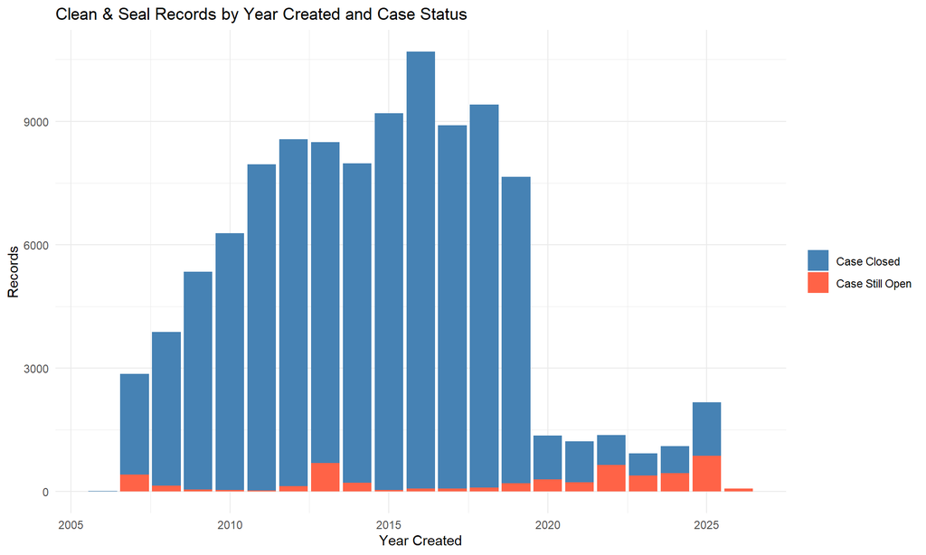

```r
cs %>%
  mutate(case_open = is.na(casecompleteddate)) %>%
  count(year_created, case_open) %>%
  mutate(case_open = ifelse(case_open, "Case Still Open", "Case Closed")) %>%
  ggplot(aes(x = year_created, y = n, fill = case_open)) +
  geom_col(position = "stack") +
  scale_fill_manual(values = c("Case Still Open" = "tomato", "Case Closed" = "steelblue")) +
  labs(title = "Clean & Seal Records by Year Created and Case Status",
       x = "Year Created", y = "Records", fill = NULL) +
  theme_minimal()
```

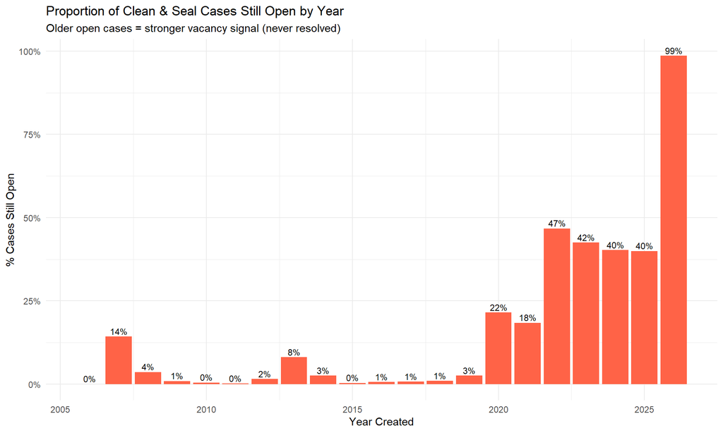

```r
# Proportion of open cases by year
cs %>%
  mutate(case_open = is.na(casecompleteddate)) %>%
  group_by(year_created) %>%
  summarise(
    total = n(),
    n_open = sum(case_open),
    pct_open = mean(case_open),
    .groups = "drop"
  ) %>%
  ggplot(aes(x = year_created, y = pct_open)) +
  geom_col(fill = "tomato") +
  geom_text(aes(label = percent(pct_open, accuracy = 1)), vjust = -0.3, size = 3) +
  scale_y_continuous(labels = percent) +
  labs(title = "Proportion of Clean & Seal Cases Still Open by Year",
       subtitle = "Older open cases = stronger vacancy signal (never resolved)",
       x = "Year Created", y = "% Cases Still Open") +
  theme_minimal()
```

# 5. Cutoff Comparison: Year-Based vs. Status-Based

## 5a. Non-CS OVS Sources (Fixed)

These don’t change with cutoff choice.

```r
vacant_viol_codes <- c("9-3904", "9-3905", "PM15-901.1", "PM15-901.2", "PM15-301",
                        "CP-102", "CP-103", "PM-102.4/1", "PM-102.4/2",
                        "PM-102.4/3", "PM-102.4/4")

viol_parcels <- violations %>%
  filter(violationcode %in% vacant_viol_codes, tolower(violationstatus) == "open") %>%
  distinct(opa_account_num) %>% pull(opa_account_num)

lic_parcels <- licenses %>%
  filter(tolower(licensestatus) == "active", revenuecode %in% c("3219", "3634")) %>%
  distinct(opa_account_num) %>% pull(opa_account_num)

cat("Violation-based OVS parcels:", comma(length(viol_parcels)), "\n")
```

```
## Violation-based OVS parcels: 4,355
```

```r
cat("License-based OVS parcels:", comma(length(lic_parcels)), "\n")
```

```
## License-based OVS parcels: 1,452
```

## 5b. Year-Based Cutoffs (Original Approach)

```r
cutoffs_year <- c(2016, 2019, 2021, 2023, NA)
cutoff_labels_year <- c("10yr (2016+)", "7yr (2019+)", "5yr (2021+)", "3yr (2023+)", "No cutoff")

results_year <- map2_dfr(cutoffs_year, cutoff_labels_year, function(yr, label) {
  if (is.na(yr)) {
    cs_ids <- cs %>% distinct(opa_account_num) %>% pull(opa_account_num)
  } else {
    cs_ids <- cs %>% filter(year_created >= yr) %>% distinct(opa_account_num) %>% pull(opa_account_num)
  }
  all_ovs <- unique(c(cs_ids, viol_parcels, lic_parcels))
  tibble(
    Method = "Year-Based",
    Cutoff = label,
    CS_parcels = length(cs_ids),
    Total_OVS1 = length(all_ovs),
    Vacancy_rate = length(all_ovs) / nrow(properties)
  )
})
```

## 5c. Status-Based Cutoffs (New Approach)

```r
# Strategy A: Open cases only (casecompleteddate is NA)
cs_open_only <- cs %>%
  filter(is.na(casecompleteddate)) %>%
  distinct(opa_account_num) %>% pull(opa_account_num)

# Strategy B: Open cases + closed cases where work was done (exclude CANCELLED)
cs_open_plus_closed_work <- cs %>%
  filter(is.na(casecompleteddate) | workorderstatus == "CLOSED") %>%
  distinct(opa_account_num) %>% pull(opa_account_num)

# Strategy C: Exclude CANCELLED only
cs_exclude_cancelled <- cs %>%
  filter(is.na(workorderstatus) | workorderstatus != "CANCELLED") %>%
  distinct(opa_account_num) %>% pull(opa_account_num)

# Strategy D: Open cases only + exclude CANCELLED
cs_open_no_cancel <- cs %>%
  filter(is.na(casecompleteddate),
         is.na(workorderstatus) | workorderstatus != "CANCELLED") %>%
  distinct(opa_account_num) %>% pull(opa_account_num)

results_status <- tribble(
  ~Method, ~Cutoff, ~cs_ids,
  "Status-Based", "A: Open cases only", cs_open_only,
  "Status-Based", "B: Open + closed w/ work done", cs_open_plus_closed_work,
  "Status-Based", "C: Exclude CANCELLED", cs_exclude_cancelled,
  "Status-Based", "D: Open & not cancelled", cs_open_no_cancel,
) %>%
  mutate(
    CS_parcels = map_int(cs_ids, length),
    Total_OVS1 = map_int(cs_ids, ~length(unique(c(.x, viol_parcels, lic_parcels)))),
    Vacancy_rate = Total_OVS1 / nrow(properties)
  ) %>%
  select(-cs_ids)
```

## 5d. Combined Comparison Table

```r
bind_rows(results_year, results_status) %>%
  mutate(
    CS_parcels = comma(CS_parcels),
    Total_OVS1 = comma(Total_OVS1),
    Vacancy_rate = percent(Vacancy_rate, accuracy = 0.1)
  ) %>%
  kable(caption = "OVS=1 under different Clean & Seal filtering strategies") %>%
  kable_styling(bootstrap_options = c("striped", "condensed"), full_width = FALSE) %>%
  pack_rows("Year-Based Cutoffs", 1, 5) %>%
  pack_rows("Status-Based Cutoffs", 6, 9)
```

OVS=1 under different Clean & Seal filtering strategies

| Method | Cutoff | CS_parcels | Total_OVS1 | Vacancy_rate |
| --- | --- | --- | --- | --- |
| **Year-Based Cutoffs** |  |  |  |  |
| Year-Based | 10yr (2016+) | 27,288 | 30,253 | 5.2% |
| Year-Based | 7yr (2019+) | 12,047 | 15,320 | 2.6% |
| Year-Based | 5yr (2021+) | 4,813 | 8,416 | 1.4% |
| Year-Based | 3yr (2023+) | 3,232 | 7,232 | 1.2% |
| Year-Based | No cutoff | 47,595 | 50,300 | 8.6% |
| **Status-Based Cutoffs** |  |  |  |  |
| Status-Based | A: Open cases only | 4,157 | 8,235 | 1.4% |
| Status-Based | B: Open + closed w/ work done | 6,539 | 10,138 | 1.7% |
| Status-Based | C: Exclude CANCELLED | 46,691 | 49,711 | 8.5% |
| Status-Based | D: Open & not cancelled | 3,763 | 8,100 | 1.4% |

## 5e. Visualization

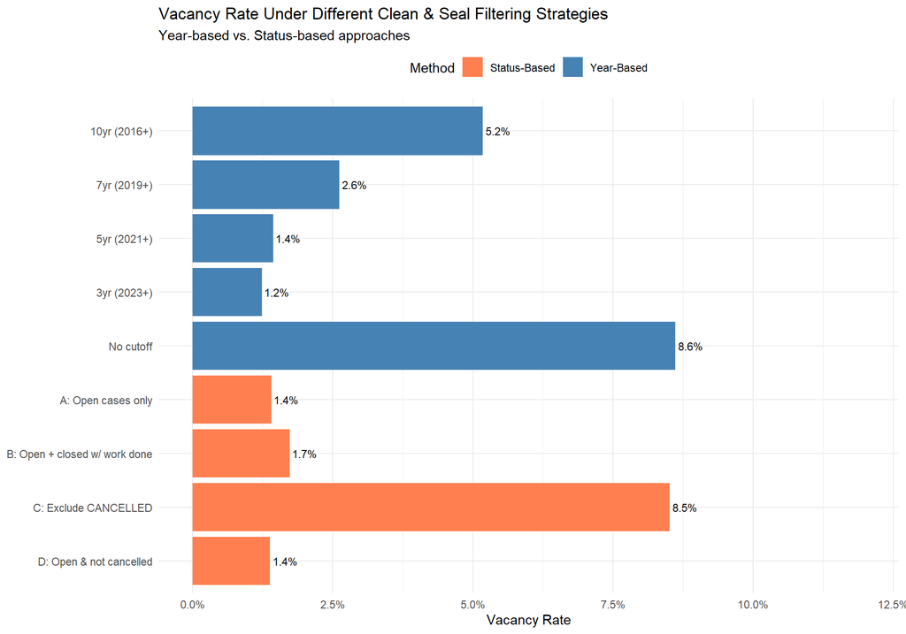

```r
bind_rows(results_year, results_status) %>%
  mutate(
    label = paste0(Cutoff, "\n(", percent(Vacancy_rate, accuracy = 0.1), ")"),
    Cutoff = factor(Cutoff, levels = rev(c(cutoff_labels_year,
                                            "A: Open cases only",
                                            "B: Open + closed w/ work done",
                                            "C: Exclude CANCELLED",
                                            "D: Open & not cancelled")))
  ) %>%
  ggplot(aes(x = Cutoff, y = Vacancy_rate, fill = Method)) +
  geom_col() +
  geom_text(aes(label = percent(Vacancy_rate, accuracy = 0.1)), hjust = -0.1, size = 3) +
  scale_y_continuous(labels = percent, limits = c(0, 0.12)) +
  scale_fill_manual(values = c("Year-Based" = "steelblue", "Status-Based" = "coral")) +
  coord_flip() +
  labs(title = "Vacancy Rate Under Different Clean & Seal Filtering Strategies",
       subtitle = "Year-based vs. Status-based approaches",
       x = NULL, y = "Vacancy Rate") +
  theme_minimal() +
  theme(legend.position = "top")
```

# 6. Hybrid Approach: Status + Year

The best strategy may combine both: use case status as the primary filter, with a year cutoff as a secondary safeguard.

```r
# Hybrid: Open cases only, but also include recent closed cases (last 5 years)
# Rationale: An open case from 2008 is likely still vacant.
#            A closed case from 2024 may have been recently resolved but property could still be vacant.

hybrid_strategies <- list(
  "Hybrid 1: Open OR created 5yr+" = cs %>%
    filter(is.na(casecompleteddate) | year_created >= 2021) %>%
    distinct(opa_account_num) %>% pull(opa_account_num),

  "Hybrid 2: Open OR created 7yr+" = cs %>%
    filter(is.na(casecompleteddate) | year_created >= 2019) %>%
    distinct(opa_account_num) %>% pull(opa_account_num),

  "Hybrid 3: (Open OR 5yr+) & not cancelled" = cs %>%
    filter((is.na(casecompleteddate) | year_created >= 2021),
           is.na(workorderstatus) | workorderstatus != "CANCELLED") %>%
    distinct(opa_account_num) %>% pull(opa_account_num),

  "Hybrid 4: (Open OR 7yr+) & not cancelled" = cs %>%
    filter((is.na(casecompleteddate) | year_created >= 2019),
           is.na(workorderstatus) | workorderstatus != "CANCELLED") %>%
    distinct(opa_account_num) %>% pull(opa_account_num)
)

results_hybrid <- imap_dfr(hybrid_strategies, function(cs_ids, label) {
  all_ovs <- unique(c(cs_ids, viol_parcels, lic_parcels))
  tibble(
    Method = "Hybrid",
    Cutoff = label,
    CS_parcels = length(cs_ids),
    Total_OVS1 = length(all_ovs),
    Vacancy_rate = length(all_ovs) / nrow(properties)
  )
})

results_hybrid %>%
  mutate(
    CS_parcels = comma(CS_parcels),
    Total_OVS1 = comma(Total_OVS1),
    Vacancy_rate = percent(Vacancy_rate, accuracy = 0.1)
  ) %>%
  kable(caption = "OVS=1 under hybrid (Status + Year) strategies") %>%
  kable_styling(bootstrap_options = c("striped", "condensed"), full_width = FALSE)
```

OVS=1 under hybrid (Status + Year) strategies

| Method | Cutoff | CS_parcels | Total_OVS1 | Vacancy_rate |
| --- | --- | --- | --- | --- |
| Hybrid | Hybrid 1: Open OR created 5yr+ | 6,833 | 10,336 | 1.8% |
| Hybrid | Hybrid 2: Open OR created 7yr+ | 13,518 | 16,760 | 2.9% |
| Hybrid | Hybrid 3: (Open OR 5yr+) & not cancelled | 5,757 | 9,635 | 1.7% |
| Hybrid | Hybrid 4: (Open OR 7yr+) & not cancelled | 12,462 | 16,064 | 2.8% |

# 7. Cross-Validation: Do Old Open Cases Overlap with Other OVS Sources?

If a parcel with an old open Clean & Seal case also has current violations or licenses, that confirms it’s still vacant. This helps validate whether keeping old open cases is justified.

```r
# Old open cases: created before 2019, case still open
old_open <- cs %>%
  filter(is.na(casecompleteddate), year_created < 2019) %>%
  distinct(opa_account_num) %>% pull(opa_account_num)

cat("Old open CS cases (pre-2019, case never closed):", comma(length(old_open)), "\n\n")
```

```
## Old open CS cases (pre-2019, case never closed): 1,757
```

```r
# How many also appear in violations or licenses?
old_open_in_viol <- sum(old_open %in% viol_parcels)
old_open_in_lic <- sum(old_open %in% lic_parcels)
old_open_in_either <- sum(old_open %in% unique(c(viol_parcels, lic_parcels)))

cat("Also have OPEN vacant violation:", comma(old_open_in_viol),
    "(", percent(old_open_in_viol / length(old_open), accuracy = 0.1), ")\n")
```

```
## Also have OPEN vacant violation: 49 ( 2.8% )
```

```r
cat("Also have Active vacant license:", comma(old_open_in_lic),
    "(", percent(old_open_in_lic / length(old_open), accuracy = 0.1), ")\n")
```

```
## Also have Active vacant license: 21 ( 1.2% )
```

```r
cat("In either violation OR license:", comma(old_open_in_either),
    "(", percent(old_open_in_either / length(old_open), accuracy = 0.1), ")\n")
```

```
## In either violation OR license: 67 ( 3.8% )
```

```r
# Comparison: Old CLOSED cases (created before 2019, case completed)
old_closed <- cs %>%
  filter(!is.na(casecompleteddate), year_created < 2019) %>%
  distinct(opa_account_num) %>% pull(opa_account_num)

cat("\nOld closed CS cases (pre-2019, case completed):", comma(length(old_closed)), "\n")
```

```
##
## Old closed CS cases (pre-2019, case completed): 40,284
```

```r
old_closed_in_either <- sum(old_closed %in% unique(c(viol_parcels, lic_parcels)))
cat("In either violation OR license:", comma(old_closed_in_either),
    "(", percent(old_closed_in_either / length(old_closed), accuracy = 0.1), ")\n")
```

```
## In either violation OR license: 1,147 ( 2.8% )
```

```r
cat("\n--- Interpretation ---\n")
```

```
##
## --- Interpretation ---
```

```r
cat("If old OPEN cases have a higher overlap rate with violations/licenses than\n")
```

```
## If old OPEN cases have a higher overlap rate with violations/licenses than
```

```r
cat("old CLOSED cases, it confirms that case status is a meaningful signal —\n")
```

```
## old CLOSED cases, it confirms that case status is a meaningful signal —
```

```r
cat("open cases genuinely track ongoing vacancy better than closed ones.\n")
```

```
## open cases genuinely track ongoing vacancy better than closed ones.
```

# 8. Most Recent Investigation Date

`mostrecentinvestigation` tells us when the city last checked on the property. This could be another useful filter.

```r
cs <- cs %>%
  mutate(investigation_date = as.Date(mostrecentinvestigation))

cat("Records with investigation date:",
    comma(sum(!is.na(cs$investigation_date))),
    "(", percent(mean(!is.na(cs$investigation_date)), accuracy = 0.1), ")\n")
```

```
## Records with investigation date: 105,287 ( 99.9% )
```

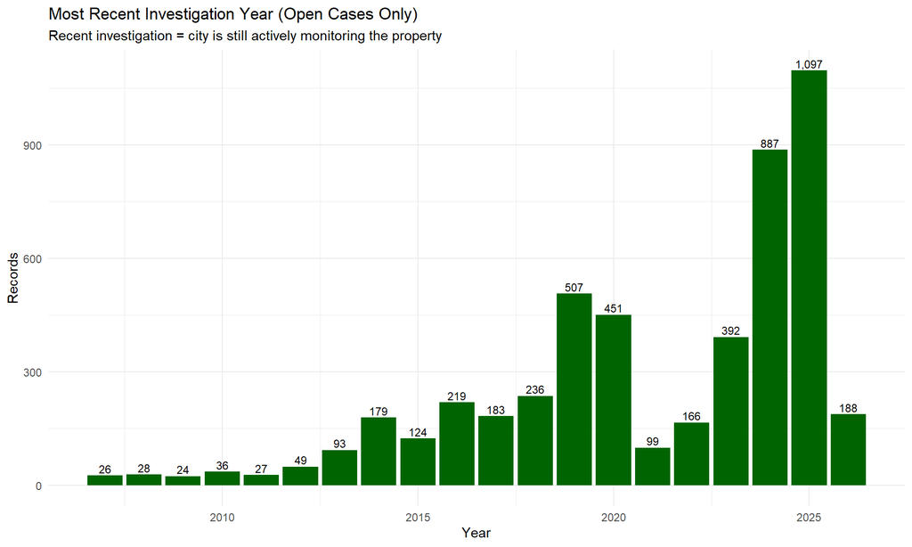

```r
# Among open cases: when was the last investigation?
cs %>%
  filter(is.na(casecompleteddate), !is.na(investigation_date)) %>%
  mutate(invest_year = year(investigation_date)) %>%
  count(invest_year) %>%
  ggplot(aes(x = invest_year, y = n)) +
  geom_col(fill = "darkgreen") +
  geom_text(aes(label = comma(n)), vjust = -0.3, size = 3) +
  labs(title = "Most Recent Investigation Year (Open Cases Only)",
       subtitle = "Recent investigation = city is still actively monitoring the property",
       x = "Year", y = "Records") +
  theme_minimal()
```

# 9. Summary & Recommendation

```r
# Build the final comparison: key strategies side by side
key_strategies <- bind_rows(results_year, results_status, results_hybrid) %>%
  arrange(desc(Vacancy_rate))

key_strategies %>%
  mutate(
    CS_parcels = comma(CS_parcels),
    Total_OVS1 = comma(Total_OVS1),
    Vacancy_rate = percent(Vacancy_rate, accuracy = 0.1)
  ) %>%
  kable(caption = "All strategies ranked by vacancy rate (descending)") %>%
  kable_styling(bootstrap_options = c("striped", "condensed"), full_width = FALSE)
```

All strategies ranked by vacancy rate (descending)

| Method | Cutoff | CS_parcels | Total_OVS1 | Vacancy_rate |
| --- | --- | --- | --- | --- |
| Year-Based | No cutoff | 47,595 | 50,300 | 8.6% |
| Status-Based | C: Exclude CANCELLED | 46,691 | 49,711 | 8.5% |
| Year-Based | 10yr (2016+) | 27,288 | 30,253 | 5.2% |
| Hybrid | Hybrid 2: Open OR created 7yr+ | 13,518 | 16,760 | 2.9% |
| Hybrid | Hybrid 4: (Open OR 7yr+) & not cancelled | 12,462 | 16,064 | 2.8% |
| Year-Based | 7yr (2019+) | 12,047 | 15,320 | 2.6% |
| Hybrid | Hybrid 1: Open OR created 5yr+ | 6,833 | 10,336 | 1.8% |
| Status-Based | B: Open + closed w/ work done | 6,539 | 10,138 | 1.7% |
| Hybrid | Hybrid 3: (Open OR 5yr+) & not cancelled | 5,757 | 9,635 | 1.7% |
| Year-Based | 5yr (2021+) | 4,813 | 8,416 | 1.4% |
| Status-Based | A: Open cases only | 4,157 | 8,235 | 1.4% |
| Status-Based | D: Open & not cancelled | 3,763 | 8,100 | 1.4% |
| Year-Based | 3yr (2023+) | 3,232 | 7,232 | 1.2% |

## Decision Framework

**Factors to consider:**

1. **Vacancy rate plausibility:** Philadelphia’s expected vacancy rate is roughly 5-8% based on prior estimates. Strategies yielding <2% are likely too aggressive; >10% may include too many false positives.
2. **Status vs. Year:** Case status is a **direct signal** of whether the issue was resolved. Year cutoff is an **indirect proxy**. Status-based filtering should be preferred when data quality supports it.
3. **CANCELLED work orders:** These represent cases where the boarding-up was never actually performed. Including them adds noise — the building may not be truly sealed/vacant.
4. **Cross-validation evidence:** If Section 7 shows that old open cases have higher overlap with current violations than old closed cases, it confirms status-based filtering captures real vacancy better.

**Recommended next step:** Pick the strategy that yields a vacancy rate closest to the 5-8% expected range, then update `02_ovs_exploration.Rmd` accordingly. Bring this comparison table to the team meeting / Fichman office hours for final decision.